# ハミルトニアンモンテカルロ法について

UPDATE: 2023-12-16 17:08:43.692134

## ハミルトニアンモンテカルロ法について

ここではハミルトニアンモンテカルロ法について、下記の書籍に記載されている第5章の事例および、演習問題の解答を試みることで、ハミルトニアンモンテカルロ法についての理解を深める。

- [基礎からのベイズ統計学―ハミルトニアンモンテカルロ法による実践的入門―](https://www.asakura.co.jp/detail.php?book_code=12212)

第5章で使用されているコードや演習問題の解答は、[出版社のサイト](https://www.asakura.co.jp/user_data/contents/12212/1.zip)のファイルから確認できる。

## 5.5章: HMC法(ハミルトニアンモンテカルロ法)

### リープフロッグ法

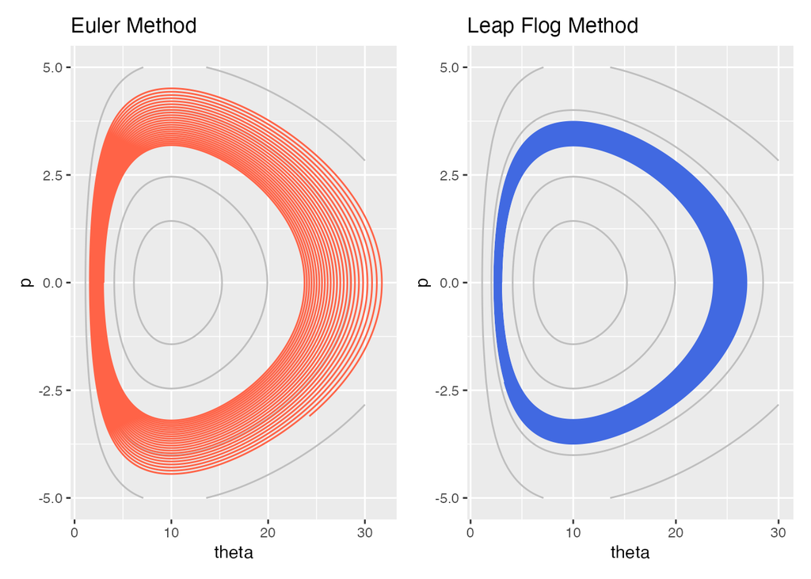

```r
library(tidyverse)
library(patchwork)

eps <- 0.01
lambda <- 1
alpha <- 11
steps <- 50000

deriv_f <- function(x, lambda, alpha) {
  return ((alpha - 1) / x - lambda)
}

x <- seq(0, 30, length.out = 100)
y <- seq(-5, 5, length.out = 100)
df <- expand.grid(x = x, y = y)

euler <- function(q, p, eps, lambda, alpha, deriv_f) {
  q_new <- q + eps * p
  p_new <- p + eps * deriv_f(q, lambda, alpha)
  return(c(q_new, p_new))
}

euler_arr <- matrix(0, ncol = 2, nrow = steps)
euler_arr[1, ] <- c(3.0, 0.0)

for (i in 2:steps) {
  euler_arr[i, ] <- euler(euler_arr[i-1, 1], euler_arr[i-1, 2], eps, lambda, alpha, deriv_f)
}

df_euler <- data.frame(
  "q" = euler_arr[,1],
  "p" = euler_arr[,2]
  )

p1 <- ggplot() +
  geom_contour(data = df,
               aes(x ,y,
                   # Hamiltonian
                   z = y^2/2 - (alpha - 1) * log(x) + lambda * x),
               breaks = c(-12, -10, -5, 0), col = 'gray') +
  geom_path(data = df_euler, aes(x = q, y = p), color = 'tomato') +
  xlab('theta') + ylab('p') + ggtitle('Euler Method')


leap_flog <- function(q, p, eps, lambda, alpha, deriv_f) {
  p_new <- p + 0.5 * eps * deriv_f(q, lambda, alpha)
  q_new <- q + eps * p_new
  p_new <- p_new + 0.5 * eps * deriv_f(q, lambda, alpha)
  return(c(q_new, p_new))
}

leap_flog_arr <- matrix(0, ncol = 2, nrow = steps)
leap_flog_arr[1, ] <- c(3.0, 0.0)

for (i in 2:steps) {
  leap_flog_arr[i, ] <- leap_flog(leap_flog_arr[i-1, 1], leap_flog_arr[i-1, 2], eps, lambda, alpha, deriv_f)
}

df_leap_flog_arr <- data.frame(
  "q" = leap_flog_arr[,1],
  "p" = leap_flog_arr[,2]
)

p2 <- ggplot() +
  geom_contour(data = df,
               aes(x ,y,
                   # Hamiltonian
                   z = y^2/2 - (alpha - 1) * log(x) + lambda * x),
               breaks = c(-12, -10, -5, 0), col = 'gray') +
  geom_path(data = df_leap_flog_arr, aes(x = q, y = p), color = 'royalblue') +
  xlab('theta') + ylab('p') + ggtitle('Leap Flog Method')

p1 | p2
```

```r
# rm(list=ls())
#
# # ガンマ分布のパラメタ
# alpha <- 11
# lambda <- 13
# #対数尤度関数のマイナス
# loggamma<-function(theta){lambda * theta - (alpha - 1) * log(theta)}
# #対数尤度関数の微分のマイナス
# Dloggamma<-function(theta){lambda - (alpha - 1)/theta}
#
# #表5.1、図5.1、図5.2のために
# #リープフロッグ(運動量、位置、高さ、ハミルトニアン)
# hmc01 <- function(ini, p, cc = 15, e = 0.05, E = loggamma, D = Dloggamma) {
#     leapfrog <- function(p, z2, e) {
#       p2 <- p  - e * D(z2) / 2
#       z2 <- z2 + e * p2
#       p2 <- p2 - e * D(z2) / 2
#       list(p2 = p2, z2 = z2)
#     }
#     z <- matrix(0, cc, 4)
#     z[1, 1] <- p
#     z[1, 2] <- z2 <- ini
#     z[1, 3] <- E(z[1, 2])
#     z[1, 4] <- H <- (p ^ 2) / 2 + z[1, 3]
#     for (j in 2:cc) {
#       pz <- leapfrog(p, z2, e)
#       z[j, 1] <- p <- pz$p2
#       z[j, 2] <- z2 <- pz$z2
#       z[j, 3] <- E(z[j, 2])
#       z[j, 4] <- H <- (p^2) / 2 + z[j, 3]
#     }
#     return(z)
#   }
# #リープフロッグの実行
# z01<-hmc01(ini = 0.1, p = 0, cc = 5, e = 0.05)
# # z02<-hmc01(ini=2.4343660,p=-1.143050, cc=15, e=0.05)
# # library(xtable)
# # xtable(z01, digits = 2)
# # xtable(z02, digits = 2)
#
# #位相空間 ハミルトニアンの計算
# Hami01 <- function(p, theta){(p * p) / 2 + loggamma(theta)}
#
# #図5.6左
# # par(mfrow=c(1,2))
# # p<-seq(0,5,0.1)
# # theta<-seq(0.05,3.0,along=p)
# # Hamiltonian<-outer(p,theta,Hami01)
# # persp(p,theta,Hamiltonian,theta=-120,phi=30,expand=0.7,col=gray(0.9),cex=1.5, ylab="θ")
#
# #図5.6右
# p <- seq(-5, 5, 0.1)
# theta <- seq(0.05, 3.0, along = p)
# Hamiltonian <- outer(p, theta, Hami01)
# contour(p, theta, Hamiltonian, nlevels = 15, cex.axis = 1.5, xlab = "p", ylab = "θ", cex.lab = 1.5)
# z01 <- hmc01(ini = 0.1, p = 0, cc = 168, e = 0.01)
# for (i in seq(1, nrow(z01), by = 3)) {
#   points(z01[i, 1], z01[i, 2], pch = 16)
# }
# # par(mfrow=c(1,1))
# #dev.copy2eps(file="z05isou06.eps",family='Japan1')
#
#
# # #表5.2
# # rownames(z01)<-1:nrow(z01)
# # z03<-z01[seq(1,nrow(z01),by=10),]
# # xtable(z03, digits = 2)
```

### HMC法の計算例(ガンマ分布モデル)

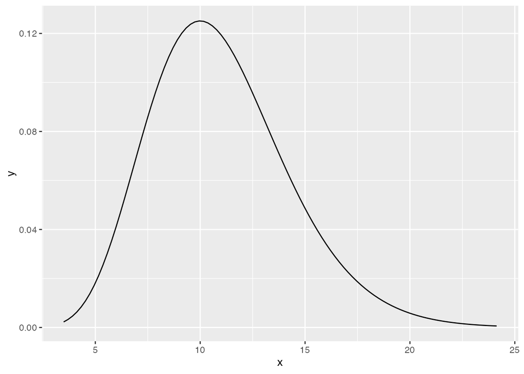

```r
library(ggplot2)
library(stats)

alpha <- 11
lambda <- 1
eps <- 0.01
L <- 100
steps <- 20000
warmup <- 5000
lf_arr <- matrix(0, ncol = 2, nrow = steps)
n_accept <- 0

gamma_x <- seq(qgamma(0.001, shape = alpha), qgamma(0.999, shape = alpha), length.out = 100)
gamma_y <- dgamma(gamma_x, shape = alpha, scale = 1/lambda)
df_gamma <- data.frame(x = gamma_x, y = gamma_y)
ggplot(df_gamma, aes(x, y)) + geom_line()
```

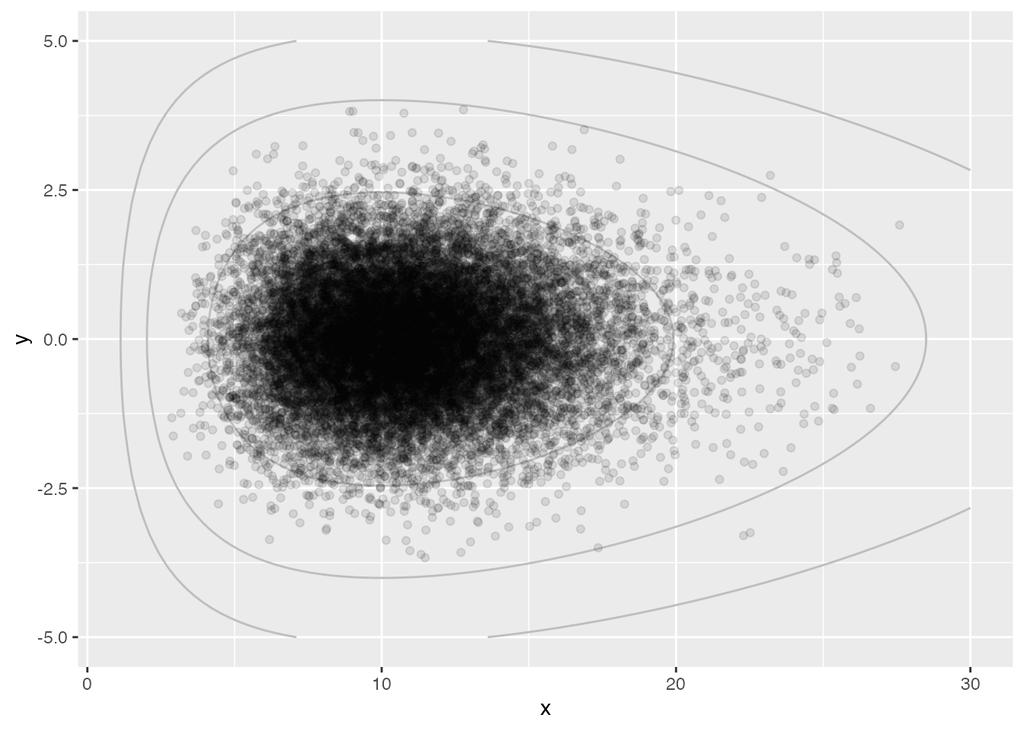

```r
deriv_f <- function(x, lambda, alpha) {
  return(-lambda + (alpha-1) / x)
}

leap_flog <- function(q, p, eps, lambda, alpha, deriv_f) {
  p_new <- p + 0.5 * eps * deriv_f(q, lambda, alpha)
  q_new <- q + eps * p_new
  p_new <- p_new + 0.5 * eps * deriv_f(q_new, lambda, alpha)
  return(c(q_new, p_new))
}

q <- 4.0
p <- 0.0
for (s in 1:steps) {
  hamiltonian_c <- p^2/2 + lambda * q - (alpha-1) * log(q)
  q_c <- q
  p_c <- p

  for (i in 1:L) {
    result <- leap_flog(q_c, p_c, eps, lambda, alpha, deriv_f)
    q_c <- result[1]
    p_c <- result[2]
  }

  hamiltonian_new <- p_c^2/2 + lambda * q_c - (alpha-1) * log(q_c)

  if (runif(1) < exp(hamiltonian_c - hamiltonian_new)) {
    q <- q_c
    p <- p_c
    hamiltonian_c <- hamiltonian_new
    n_accept <- n_accept + 1
  }

  lf_arr[s,] <- c(q, p)
  p <- rnorm(1,0,1)
}

x <- seq(0, 30, length.out = 100)
y <- seq(-5, 5, length.out = 100)
df <- expand.grid(x = x, y = y)
df_leap_flog <- data.frame(q = lf_arr[,1], p = lf_arr[,2])
ggplot() +
  geom_contour(data = df,
               aes(x ,y,
                   # Hamiltonian
                   z = y^2/2 - (alpha - 1) * log(x) + lambda * x),
               breaks = c(-12, -10, -5, 0), col = 'gray') +
  geom_point(data = df_leap_flog, aes(q, p), alpha = 0.1)
```

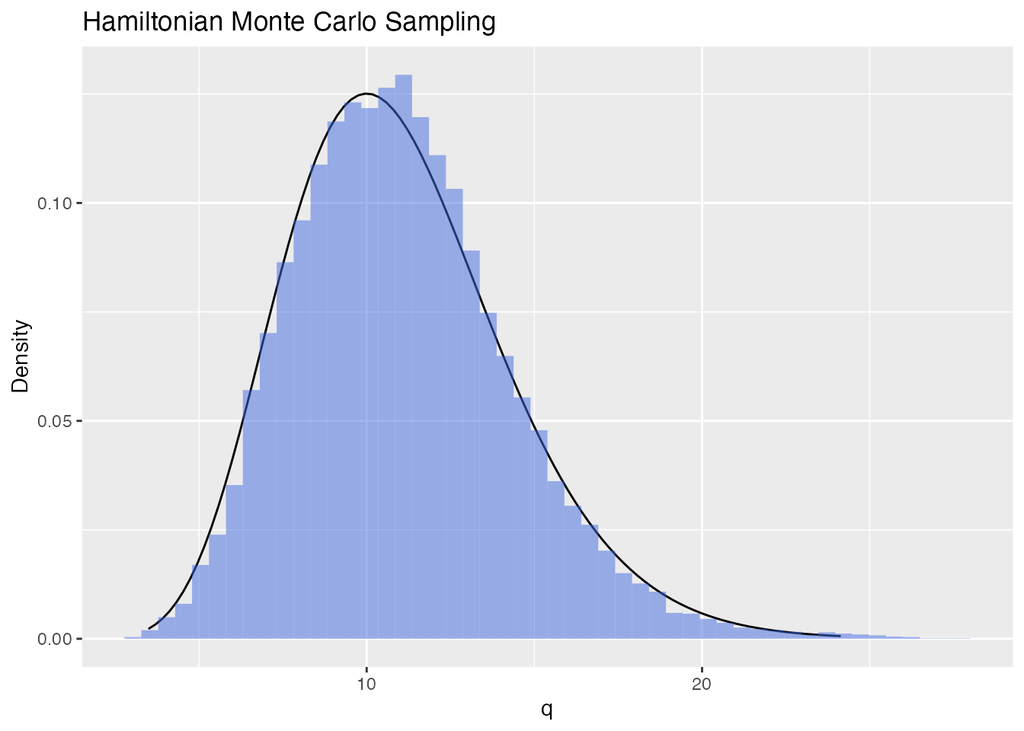

```r
ggplot() +
  geom_line(data = df_gamma, aes(x, y)) +
  geom_histogram(data = df_leap_flog, aes(x = q, y = ..density..),
                 alpha = 0.5, bins = 50, fill = 'royalblue') +
  labs(x = "q", y = "Density", title = 'Hamiltonian Monte Carlo Sampling')
```

```r
#
# #ハミルトニアンモンテカルロ
# #位相空間 ハミルトニアンの計算
# Hami01<-function(p,theta){(p*p)/2 +loggamma(theta)}
#
# # N=スカラー、サンプリングする乱数の数
# # ini=母数ベクトルの初期値
# # E=関数、対数尤度関数のマイナス（母数ベクトルを入力、スカラーを返す）
# # D=関数、対数尤度関数の微分のマイナス（母数ベクトルを入力、ベクトルを返す）
# # L=スカラー、遷移内の移動時間
# # epsi=リープフロッグ法の精度
# hmc <- function(N,ini,E,D,L=100,epsi=0.01){
#   leapfrog <- function(r,z2,e){
#     r2 <- r  - e * D(z2) / 2
#     z2 <- z2 + e * r2
#     r2 <- r2 - e * D(z2) / 2
#     list(r2=r2,z2=z2)
#   }
#   p<-length(ini)
#   z<- matrix(0,N,p); rr<- matrix(0,N,p);
#   z[1,] <- ini
#   co<- 1; #最初は採択
#   for(i in 2:N) {
#     r <- rr[i-1,]<-rnorm(p)
#     H <- sum(r^2)/2 + E(z[i-1,])
#     #e <- sample(c(-1,1), 1) * runif(1, 0.9, 1.1) * epsi
#     e <- epsi
#     z2 <- z[i-1,]
#     #LL <- sample(L:(L*2),1)
#     LL <- L
#     for(j in 1:LL) {
#       rz<-leapfrog(r,z2,e)
#       r <- rz$r2
#       z2<- rz$z2
#     }
#     dH <- H - (sum(r^2)/2 + E(z2));
#     if (runif(1) < exp(dH)) {
#       z[i,]<-z2; co<-co+1
#     }else{
#       z[i,]<-z[i-1,]
#     }
#   }
#   ac<-co/N
#   return(list(z=z,rr=rr,ac=ac))
# }
#
# #ガンマ分布モデルのための関数の設定
# alpha <- 11;
# lambda <- 13;
# #対数尤度関数のマイナス
# loggamma<-function(theta){lambda*theta-(alpha-1)*log(theta)}
# #対数尤度関数の微分のマイナス
# Dloggamma<-function(theta){lambda-(alpha-1)/theta}
#
#
# #表5.3
# set.seed(1234)
# fit<-hmc(N=100,ini=c(2.5),E=loggamma,D=Dloggamma)
# mean(fit$z[2:100])
# mean(fit$rr[2:100])
# print(fit$ac)
# fit$z[1:3]
# fit$rr[1:3]
#
# #図5.7左　フリーハンドで書いている部分があるので再現は難しい
# # par(mfrow=c(1,2))
# # p<-seq(-5,5,0.1);theta<-seq(0.05,3.0,along=p)
# # Hamiltonian<-outer(p,theta,Hami01)
# # contour(p,theta,Hamiltonian,nlevels = 15,cex.axis=1.5,xlab="p",ylab="θ",cex.lab=1.5,xlim=c(-5,5),ylim=c(0.05,3))
# # par(new=T)
# # #plot(fit$rr[1:3],fit$z[1:3],type="p",xlim=c(-5,5),ylim=c(0.05,3),xlab="",ylab="",cex.axis=1.5,cex.lab=1.5)
# # points(fit$rr[1:3],fit$z[1:3],pch=16,cex=2)
# # points(-4.44,fit$z[2],pch=15,cex=2)
# # points(-1.5,fit$z[3],pch=15,cex=2)
# # text(fit$rr[1]+0.1,fit$z[1]+0.1, "t=1",cex=1.5)
# # text(fit$rr[2]+0.1,fit$z[2]+0.1,"t=2",cex=1.5)
# # text(fit$rr[3]+0.1,fit$z[3]+0.1,"t=3",cex=1.5)
# # #xy<-locator(20)
# # #for (i in 1:19){segments(xy$x[i],xy$y[i],xy$x[i+1],xy$y[i+1],lwd=2.5)}
# # #xyxy<-locator(1)
# # #arrows(xy$x[20],xy$y[20],xyxy$x[1],xyxy$y[1],lwd=2.5)
#
# #図5.7右
# p<-seq(-5,5,0.1);theta<-seq(0.05,3.0,along=p)
# Hamiltonian<-outer(p,theta,Hami01)
# contour(p,theta,Hamiltonian,nlevels = 15,cex.axis=1.5,xlab="p",ylab="θ",cex.lab=1.5,xlim=c(-5,5),ylim=c(0.05,3))
# par(new=T)
# plot(fit$rr,fit$z,type="b",xlim=c(-5,5),ylim=c(0.05,3),xlab="",ylab="",cex.axis=1.5,cex.lab=1.5)
# par(mfrow=c(1,1))
# #dev.copy2eps(file="z05isou07.eps",family='Japan1')
#
#
# #図5.8 ガンマ分布　トレースライン
# fit<-hmc(N=1000,ini=c(3.0),E=loggamma,D=Dloggamma)
# plot(fit$z,type="l",xlab="t",ylab="θ",cex.axis=1.5,cex.lab=1.5)
# #dev.copy2eps(file="z05tore08.eps",family='Japan1')
# fit$ac; #採用率
```

## 5.7: 章末問題

下記の方が回答を作成したので参考にさせていただいた。

-[基礎からのベイズ統計学 章末問題解答](https://github.com/yukirin/Bayesianstatistics)

### 5.7.8: 章末問題

事後分布$p=10.2, q=5.8$のベータ分布。初期位置$\theta^{(0)}=0.1$とし、最初は静止しているものとして$p(1)=0$とする。定数は$\epsilon=0.05,L=5$としてリープフロッグ法を実行し、移動の様子を報告する。

```r
# # 基礎からのベイズ統計学第5章 5.7 (8)
#
# # ベータ分布
# beta_p = 10.2
# beta_q = 5.8
#
# # HMC
# sig = 0.05
# L = 5
#
# init_theta = 0.1
# init_p = 0
#
# # 負の対数事後分布
# h <- function(theta) {
#   a = -(beta_p - 1) * log(theta)
#   b = -(beta_q - 1) * log(1 - theta)
#
#   return(a + b)
# }
#
# # 負の対数事後分布の微分
# h_dash <- function(theta) {
#   # ゼロ除算回避
#   sigma = 0.000001
#
#   a = -(beta_p - 1) / ifelse(theta == 0, sigma, theta)
#   b = (beta_q - 1) / ifelse(1 - theta == 0, sigma, 1 - theta)
#   return(a + b)
# }
#
# # ハミルトニアン
# hamiltonian <- function(theta, p) {
#   return(h(theta) + (1 / 2) * (p^2))
# }
#
# leapfrog <- function(theta, p) {
#     p = p - (sig / 2) * h_dash(theta)
#     theta = theta + sig * p
#     p = p - (sig / 2) * h_dash(theta)
#
#   return(list(theta, p))
# }
#
# thetas = c(init_theta)
# ps = c(init_p)
# h_thetas = c(h(init_theta))
# hamils = c(hamiltonian(init_theta, init_p))
#
# for (i in 1:L) {
#   moved = leapfrog(tail(thetas, 1), tail(ps, 1))
#   thetas = append(thetas, moved[[1]])
#   ps = append(ps, moved[[2]])
#   h_thetas = append(h_thetas, h(moved[[1]]))
#   hamils = append(hamils, hamiltonian(moved[[1]], moved[[2]]))
# }
#
# for (i in 0:L + 1) {
#   print(sprintf("p=%f θ=%f h(θ)=%f H(θ,p)=%f", ps[i], thetas[i], h_thetas[i], hamils[i]))
# }
# Warning: NaNs producedWarning: NaNs produced[1] "p=0.000000 θ=0.100000 h(θ)=21.689513 H(θ,p)=21.689513"
# [1] "p=3.119088 θ=0.208333 h(θ)=15.552618 H(θ,p)=20.416972"
# [1] "p=4.425835 θ=0.411909 h(θ)=10.708162 H(θ,p)=20.502170"
# [1] "p=4.789751 θ=0.650917 h(θ)=9.001972 H(θ,p)=20.472829"
# [1] "p=3.957766 θ=0.890884 h(θ)=11.696624 H(θ,p)=19.528579"
# [1] "p=5.905886 θ=1.046693 h(θ)=NaN H(θ,p)=NaN"
```

### 5.7.9: 章末問題

前問の状態で、$\epsilon=0.01,L=15$としてリープフロッグ法を実行し、遷移の状態を観察する。

```r
# # 基礎からのベイズ統計学第5章 5.7 (9)
#
# # ベータ分布
# beta_p = 10.2
# beta_q = 5.8
#
# # HMC
# sig = 0.01
# L = 15
#
# init_theta = 0.1
# init_p = 0
#
# # 負の対数事後分布
# h <- function(theta) {
#   a = -(beta_p - 1) * log(theta)
#   b = -(beta_q - 1) * log(1 - theta)
#
#   return(a + b)
# }
#
# # 負の対数事後分布の微分
# h_dash <- function(theta) {
#   # ゼロ除算回避
#   sigma = 0.000001
#
#   a = -(beta_p - 1) / ifelse(theta == 0, sigma, theta)
#   b = (beta_q - 1) / ifelse(1 - theta == 0, sigma, 1 - theta)
#   return(a + b)
# }
#
# # ハミルトニアン
# hamiltonian <- function(theta, p) {
#   return(h(theta) + (1 / 2) * (p^2))
# }
#
# leapfrog <- function(theta, p) {
#   p = p - (sig / 2) * h_dash(theta)
#   theta = theta + sig * p
#   p = p - (sig / 2) * h_dash(theta)
#
#   return(list(theta, p))
# }
#
# thetas = c(init_theta)
# ps = c(init_p)
# h_thetas = c(h(init_theta))
# hamils = c(hamiltonian(init_theta, init_p))
#
# for (i in 1:L) {
#   moved = leapfrog(tail(thetas, 1), tail(ps, 1))
#   thetas = append(thetas, moved[[1]])
#   ps = append(ps, moved[[2]])
#   h_thetas = append(h_thetas, h(moved[[1]]))
#   hamils = append(hamils, hamiltonian(moved[[1]], moved[[2]]))
# }
#
# for (i in 0:L + 1) {
#   print(sprintf("p=%f θ=%f h(θ)=%f H(θ,p)=%f", ps[i], thetas[i], h_thetas[i], hamils[i]))
# }
# [1] "p=0.000000 θ=0.100000 h(θ)=21.689513 H(θ,p)=21.689513"
# [1] "p=0.847432 θ=0.104333 h(θ)=21.322410 H(θ,p)=21.681480"
# [1] "p=1.627688 θ=0.116949 h(θ)=20.340373 H(θ,p)=21.665056"
# [1] "p=2.302081 θ=0.136887 h(θ)=19.001717 H(θ,p)=21.651506"
# [1] "p=2.863870 θ=0.162990 h(θ)=17.543410 H(θ,p)=21.644286"
# [1] "p=3.324552 θ=0.194164 h(θ)=16.115459 H(θ,p)=21.641782"
# [1] "p=3.700986 θ=0.229481 h(θ)=14.793109 H(θ,p)=21.641757"
# [1] "p=4.009019 θ=0.268184 h(θ)=13.606634 H(θ,p)=21.642750"
# [1] "p=4.261531 θ=0.309662 h(θ)=12.563682 H(θ,p)=21.644007"
# [1] "p=4.468356 θ=0.353415 h(θ)=11.662079 H(θ,p)=21.645180"
# [1] "p=4.636741 θ=0.399029 h(θ)=10.896439 H(θ,p)=21.646121"
# [1] "p=4.771857 θ=0.446150 h(θ)=10.261459 H(θ,p)=21.646767"
# [1] "p=4.877183 θ=0.494466 h(θ)=9.753620 H(θ,p)=21.647078"
# [1] "p=4.954749 θ=0.543693 h(θ)=9.372236 H(θ,p)=21.647003"
# [1] "p=5.005208 θ=0.593561 h(θ)=9.120404 H(θ,p)=21.646457"
# [1] "p=5.027730 θ=0.643797 h(θ)=9.006242 H(θ,p)=21.645278"
```

$p=10.2, q=5.8$のベータ分布をHMC法によってシミュレーションし、EAP推定値と理論値である約0.638と比較しなさい。$T=1000,L=100,\epsilon=0.01$とする。

```r
# # 基礎からのベイズ統計学第5章 5.7 (10)
# # ベータ分布
# beta_p <- 10.2
# beta_q <- 5.8
#
# # HMC
# sig <- 0.01
# L <- 100
# Time <- 1000
# burnin <- 100
#
# init_theta <- 0.5
#
# # 負の対数事後分布
# h <- function(theta) {
#   a <- -(beta_p - 1) * log(theta)
#   b <- -(beta_q - 1) * log(1 - theta)
#
#   return(a + b)
# }
#
# # 負の対数事後分布の微分
# h_dash <- function(theta) {
#   # ゼロ除算回避
#   sigma = 0
#
#   a <- -(beta_p - 1) / ifelse(theta == 0, sigma, theta)
#   b <- (beta_q - 1) / ifelse(1 - theta == 0, sigma, 1 - theta)
#   return(a + b)
# }
#
# # ハミルトニアン
# H <- function(theta, p) {
#   return(h(theta) + (1 / 2) * (p^2))
# }
#
# # リープ・フロッグ法
# leapfrog <- function(theta, p) {
#   p <- p - (sig / 2) * h_dash(theta)
#   theta = theta + sig * p
#   p <- p - (sig / 2) * h_dash(theta)
#
#   return(c(theta, p))
# }
#
# pred <- function(theta, p) {
#   moved <- c(theta, p)
#   for (i in 1:L) {
#     moved <- leapfrog(moved[1], moved[2])
#   }
#   return(moved)
# }
#
# HMC <- function() {
#   thetas <- c(init_theta)
#   for (i in 1:Time) {
#     random_p <- rnorm(1, 0, 1)[1]
#     candidate <- pred(tail(thetas, 1), random_p)
#
#     r <- exp(H(tail(thetas, 1), random_p) - H(candidate[1], candidate[2]))
#
#     next_theta <- ifelse(runif(1) < r, candidate[1], tail(thetas, 1))
#     thetas <- append(thetas, next_theta)
#   }
#   return(thetas)
# }
#
# result <- HMC()
# print(mean(tail(result, Time - burnin)))
# [1] 0.6392119
```